# Coursework Report

*N* removed NAs: 2

*N* removed typo: 1

*N* removed <18: 19

*N* total clean: 129

| Group | *N* | *M*<sub>age</sub> | *M*<sub>rating</sub> |
| --- | --- | --- | --- |
| Control | 61 | 20.41 | 5.51 |
| Experim | 68 | 21.29 | 6.33 |

**Main analysis results**

*t*(127) = -5.89, *p* < .001

[interactive chart not shown]

[figure not shown]

[interactive chart not shown]

# Coursework Report

Analysing Data, Spring 2020

# Methods

## Participants

Table 1: Descriptive Statistics by Condition

| CONDITION | n | Percentage | *M*<sub>age</sub> | *SD*<sub>age</sub> |
| --- | --- | --- | --- | --- |
| control | 61 | 47.29 | 20.41 | 1.84 |
| experimental | 68 | 52.71 | 21.29 | 2.17 |

## Design

The experiment was researching into whether colour influences attractiveness. Participants were randomly allocated to either the control or experimental condition, in which they viewed a black-and-white photo of a man on a white or red background for 5 seconds and then reported their perceptions of the man’s attractiveness. Colour, being independent categorical variable, is a factor that had two levels: the red for the experimental condition and white for the control condition. To assess attractiveness, participants were asked 3 questions which they rated on a 9 point scale in which a higher rating meant they perceived it to be more attractive. The operational hypothesis for this study is does viewing a different colour frame around an image of a man influence the mean ratings of his attractiveness? This will be statistically analysed with a t-test.

# Results

The results of this experiment show that participants in the experimental condition rated the man in the picture to be more attractive than those in the control condition.

Table 2: Composite score by condition

| CONDITION | mean | sd | min | max |
| --- | --- | --- | --- | --- |
| control | 5.51 | 0.73 | 4 | 7.33 |
| experimental | 6.33 | 0.83 | 4 | 8.33 |

This composite score was calculated by finding the mean of all three scores for each participant, and then this data was grouped by condition to give an overall summary of the mean and sd for both conditions. This composite score was then used to create a means plot, that shows the variation in the means for the conditions, which can be seen below.

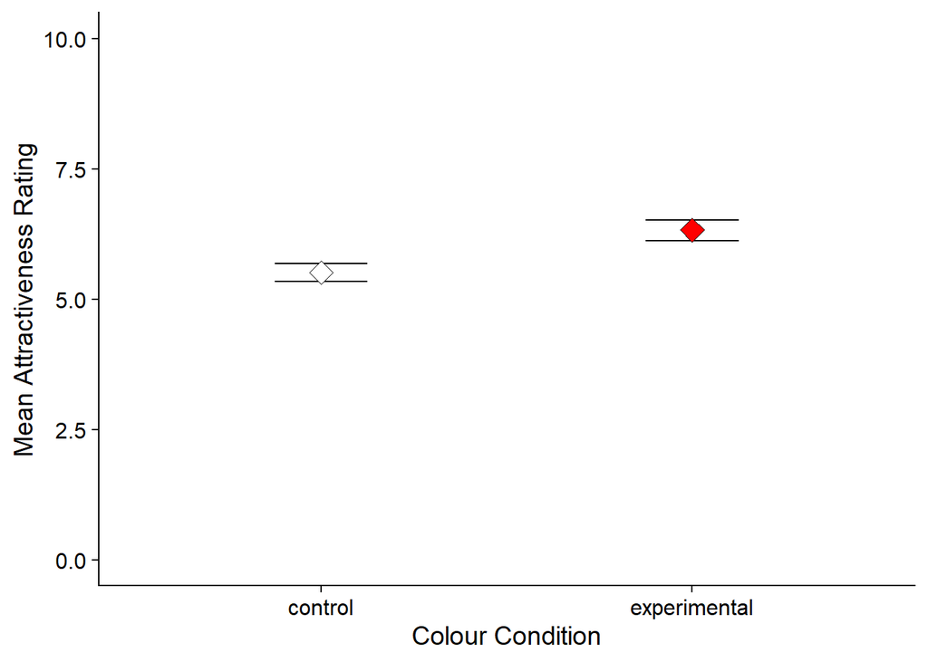

We investigated whether colour had an influence on perceived attractiveness using an independent *t*-test. The *t*-test indicated that the mean rating of attractiveness for the control group (M = 5.51) was smaller than for the experimental group (M = 6.33), with M<sub>diff</sub> = -0.82. The difference in mean rating of attractiveness was significant (*t* (127) = -5.89, 95% CI [-1.09, -0.54], *p* = < .001). This means that colour does have an influence on the perceived attractiveness of a man, thus supporting the hypothesis.

# Discussion

The reason for this research was to investigate, like many others have done before, whether the colour red has an influence on attractiveness as we predicted. The results from this experiment provide evidence that colour, specifically red, have an effect on whether women perceive a man to be attractive or not. Those in the experimental (red) condition rated the man to be more attractive than those in the control (white) condition, producing a statistically significant difference, thus providing support for the hypothesized red effect. This experiment is a close replication of the original study (specifically experiment 1) carried out by Elliot, Kayser, Greitemeyer, Lichtenfeld, Gramzow, Maier and Liu (2010). Our results in comparison to the original study are quite similar, both producing statistically significant results which provide evidence for the red effect phenomena. This is further supported by other studies such as Roberts, Owen and Havlicek (2010) who not only established that women were influenced by the colour red but also showed that this effect extends to males perceptions of females, and Elliot and Niesta (2008), in which 5 experiments were carried out that all provided strong evidence for the red effect. This research has important implications for mate evaluation as previous research into the colour red (Little & Hill, 2007) has found that it is often linked to power, status and dominance. This is seen as a core aspect of mate evaluation, as female attention is more easily caught by someone viewed as of a high status (DeWall & Maner, 2008) it could be argued this is because they are seen as more desirable as they can provide financial support and resources.

However, the hypothesized red effect has many inconsistencies whereby other replications have not produced results which support the effect. Hesslinger, Goldbach and Carbon (2015) carried out two experiments investigating into the red effect, in which neither produced a statistically significant effect of the colour red on perceived attractiveness. This is further supported in other studies (Peperkoorn, Roberts & Pollet, 2016; Lynn, Giebelhausen, Garcia, Li, & Patumanon, 2016) where there is no significant difference between the ratings of attractiveness and the independent variables. The differences in the effect sizes of different studies could be explained by methodological variations such as using different chromatic colour comparisons or variations of the surrounding light (Elliot, 2015).

The limitations of this study, and similar studies, must also be considered as a way on considering whether this effect can be deemed real or not. As already noted, there is already a fairly large body of literature that has not found similar results to those produced by Elliot et al (2010) which not only questions the red effect itself but also the integrity of the research. Francis (2013) suggested that the flawless series of replications carried out by Elliot et al (2010) lack sufficient power to support this claim, and therefore indicates there may have been some publication bias, in which null findings were not reported or the experiments were not conducted correctly. In response to this Elliot and Maier (2013) not only pointed out how the results have been replicated successfully in many other laboratories (such as this study), but also carried out another experiment with a larger sample. Although this experiment did not produce significant results, the study was deemed inconclusive as the results were in the same direction just not as strong as the initial study. Furthermore, our study, like Elliot et al’s (2010) lacked in ecological validity by only using one photo of an attractive man, therefore restricting the visual stimulus to one particular type of attractive suitor which does not reflect reality. Not only do people have different preferences and beliefs for what is deemed to be attractive but it is also unknown if the effect of red would still be found to occur in everyday encounters with people that may not normally be seen as attractive. This calls into question the generalisability of this research, and therefore its practical uses, however this could be dealt with by conducting further research that uses a different image and then conducting a meta-analysis of the different results to see if there is an overall trend (Lehmann, Elliot & Calin-Jageman, 2018).

In conclusion, while there may be some contradicting research to the results found by Elliot et al (2010), there is also a lot of research that supports (such as this study) and extends on the original findings. This therefore means the red effect must be further researched in an attempt to find a more conclusive and accepted decision on the matter, which is believed to be necessary to understanding mate evaluation (Little & Hill, 2007).

# References

DeWall, C. & Maner, J. (2008). High Status Men (but Not Women) Capture the Eye of the Beholder. *Evolutionary Psychology, 6* 328-341. https://doi.org/10.1177/147470490800600209

Elliot A. J. (2015). Color and psychological functioning: a review of theoretical and empirical work. *Front. Psychol* 6:3389 doi.org/10.3389/fpsyg.2015.00368

Elliot, A. J., & Niesta, D. (2008). Romantic red: Red enhances men’s attraction to women.. *Journal of Personality and Social Psychology, 95*(5), 1150-1164. https://doi.org/10.1037/0022-3514.95.5.1150

Elliot, A. J., Niesta Kayser, D., Greitemeyer, T., Lichtenfeld, S., Gramzow, R. H., Maier, M. A., & Liu, H. (2010). Red, rank, and romance in women viewing men. *Journal of Experimental Psychology: General, 139*(3), 399.

Elliot, A. J., & Maier, M. A. (2013). The red-attractiveness effect, applying the Ioannidis and Trikalinos (2007b) test, and the broader scientific context: A reply to Francis (2013). *Journal of Experimental Psychology: General, 142*(1), 297-300. https://doi.org/10.1037/a0029592

Francis, G. (2013). Publication Bias in “Red, Rank, and Romance in Women Viewing Men,” by Elliot et al. (2010). *Journal of Experimental Psychology: General, 142* 292-6. 10.1037/a0027923.

Hesslinger, V.M., Goldbach, L. & Carbon, C. (2015). Men in red: A reexamination of the red-attractiveness effect. *Psychon Bull Rev 22* 1142-1148. https://doi.org/10.3758/s13423-015-0866-8

Lehmann, G. K., Elliot, A. J., & Calin-Jageman, R. J. (2018). Meta-Analysis of the Effect of Red on Perceived Attractiveness. *Evolutionary Psychology.* https://doi.org/10.1177/1474704918802412

Little, A. & Hill, R. (2007). Attribution to Red Suggests Special Role in Dominance Signalling. *Journal of Evolutionary Psychology, 5,* 1780-2082. http://dx.doi.org/10.1556/JEP.2007.1008

Lynn, M., Giebelhausen, M., Garcia, S., Li, Y., & Patumanon, I. (2016). Clothing Color and Tipping: An Attempted Replication and Extension. *Journal of Hospitality & Tourism Research, 40*(4), 516-524. https://doi.org/10.1177/1096348013504001

Peperkoorn, L. & Roberts, S. & Pollet, T. (2016). Revisiting the Red Effect on Attractiveness and Sexual Receptivity: No Effect of the Color Red on Human Mate Preferences. *Evolutionary Psychology. 14* 10.1177/1474704916673841.

Roberts, S. C., Owen, R. C., & Havlicek, J. (2010). Distinguishing between Perceiver and Wearer Effects in Clothing Color-Associated Attributions. *Evolutionary Psychology.* https://doi.org/10.1177/147470491000800304